# America’s Cup Predictor

3/3/2021

## Background

- **What is the America’s cup?**
  - World’s most prestigious sailing event
  - The Defender is the previous winner
  - The Challenger is the winner of the Challenger Selection series
  - Queen Victoria once asked who was in 2nd place, the reply… “You Majesty, there is no second”
- **Why Predict the 2021 Winner**
  - 36th America’s Cup will be held in Auckland in March 2021
  - 3 teams are Challenging for the right to face the Defender

[figure not shown]

## App Background

- **Hypothesis**  
  -The more teams in the Challenger selection series, the tougher the competition  
  -The tougher the competition, the better chance the Challenger has of winning
- **Data**
  - The results of previous America’s Cups from 1851 to 2017 were obtained from a variety of sources. Refer to the app for more details.
- **Model**
  - The outcome of the Americas Cup is binary - win or lose. The winning margin is irrelevant.
  - Therefore a Logistical Regression model was chosen with the ratio of Challengers to Defenders as the predictor and winner as the model output.

## App and Model Example

- The user enters **1** Defender and **5** Challengers
- Challenger to Defender Ratio is calculated as 5
- The Logistic Regression model predicts 1.1636562
- Therefore the winner is the **Defender**

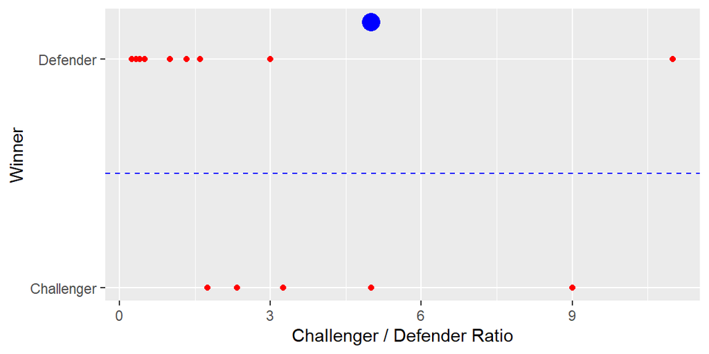

## Results

- **Comparing against historical results**
  - The last America’s cup held in Auckland was in 2003
  - **1** Defender and **9** Challengers
  - The Defender, Team New Zealand lost to the Challenger, Alinghi (Switzerland)
  - Predicted winner : **Challenger**
- **Who will win the 2021 America’s Cup?**
  - **1** Defender and **3** Challengers
  - The Defender, Emirates Team New Zealand will face the Challenger, Luna Rossa Prada Pirelli (Italy)
  - Predicted winner : **Defender**